# STAT 330 | Statistical Modeling 2 | Homework Rules

## General Information

Put all R packages you need in the `setup` R code chunk (Note: the “setup” code chunk below has the parameter `include=FALSE`, so it will not show up in the generated HTML file.)

To generate this .qmd file into an HTML file (not a PDF file), click the “Render” button (top left).

Before submitting an assignment, make sure to SPELLCHECK your document (top left “ABC” button with a check mark).

## Including R Code

Put all R code in chunks like this:

```r
my_data <- as.data.frame(cbind(c(3, 5, 7, 9), c(1, 2, 3, 4)))
```

When formatting your R code, you should follow the tidyverse style guide found here: https://style.tidyverse.org/index.html. A few key formatting rules from the Guide:

- You should put spaces after every comma and before and after equality/inequality sign.
- Your R code should not exceed 80 characters per line (you can check this by looking at the second number at the bottom left of this page: ##:**##**). You can also add a vertical line at 80 characters in your RMD file to help you know when you need to start a new code line by going to Tools->Global Options->Code->Display then check the box “Show margin” and change the “Margin column” to 80.
- When adding comments to your R code on the same line you should indent two spaces and then add the comment.

Here is an example of BAD code:

```r
#this is my poorly formatted comment
test<-c(1,2,3,10)#this is my poorly formatted comment and code
thisisavariablename <- cbind(c(3, 5, 7, 9), c(1, 2, 3, 4), c(2, 4, 6, 8), c(10, 8, 6, 4))#this is my poorly formatted comment and code
```

Here is an example of GOOD code:

```r
# this is my properly formatted comment
test <- c(1, 2, 3, 10)  # this is my properly formatted comment and code
this_is_a_variable_name <- cbind(c(3, 5, 7, 9),
                                 c(1, 2, 3, 4),
                                 c(2, 4, 6, 8),
                                 c(10, 8, 6, 4))
# above is properly formatted code (does not exceed 80 lines)
```

## Including Plots

You can embed plots into qmd documents. When you do, you should make sure the x- and y-axes have meaningful labels (including appropriate units).

Here is an example of a BAD plot:

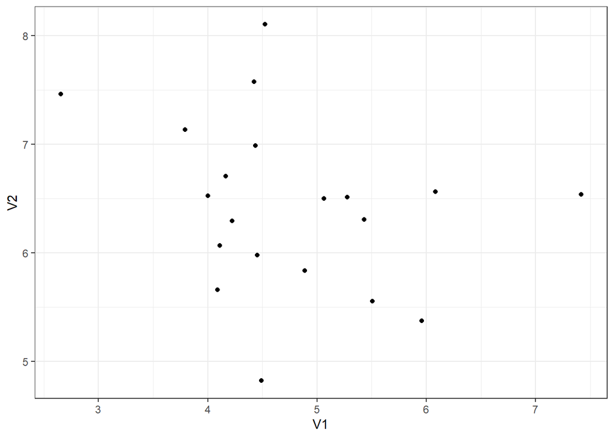

```r
set.seed(1234)
my_plot_data <- as.data.frame(cbind(rnorm(20, 5, 1), rnorm(20, 7, 1)))

ggplot(data = my_plot_data) +
  theme_bw() +  # I, personally, like this theme
  geom_point(mapping = aes(x = V1, y = V2))
```

```r
# this plot is bad because it does not have meaningful x- and y-axis labels - we have no idea what
#     this plots is trying to show.
```

Here is an example of a GOOD plot:

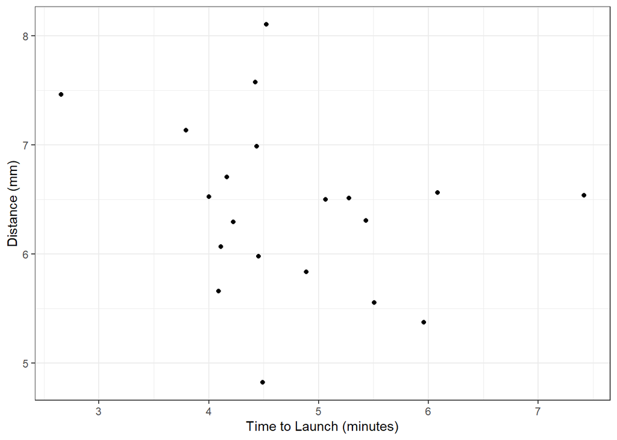

```r
ggplot(data = my_plot_data) +
  geom_point(mapping = aes(x = V1, y = V2)) +
  theme_bw() +  # I, personally, like this theme
  xlab("Time to Launch (minutes)") +
  ylab("Distance (mm)")
```

## Formatting Text

R Markdown has built-in, useful ways to format text. Here are just a few:

# This is a header with a very large font

## This is a header with a slightly smaller font

### This is a header with a smaller font than the last header (and so forth)

This is an unordered (bulletted) list:

- this is an item in the list
  - this is a sub-item in the list
- this is an item in the list

This is an ordered (numbered) list:

1. this is an item in the list
2. this is an item in the list

You can also use LaTeX code in R Markdown. You will be asked to write out equations in R Markdown for many of your homework assignments. Here is an example of what that might look like:

$\log(\text{LifeExp}_i) = \beta_0 + \beta_1 \times \text{Precip}_i + \epsilon_i$ where $\epsilon_i \overset{iid}{\sim} N(0, \sigma^2)$

$\log(\widehat{\text{LifeExp}}_i) = 3.43 + 74.63 \times \text{Precip}_i$

If you are ever unsure how to format something using LaTeX, Googling the question will almost always be helpful. You may certainly ask me or the TAs for help, as well.